# AN/BI 333/733: Fall 2020 Assigned Sub-Populations

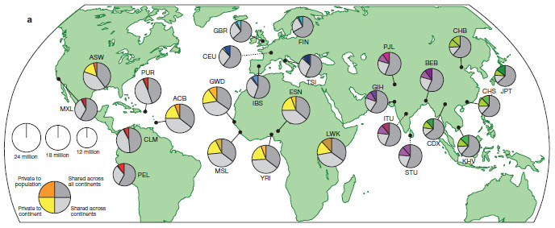

These are your assigned 1000 Genomes Project sub-populations for our investigations of *ACE2* and *TMPRSS2* this semester! I’ve tried my best to accommodate personal interests in a particular sub-population, but there are always some that are more popular than others. If there’s another sub-population you’d rather work on, please contact me directly to discuss switching.

- Ana Barun - **TSI: Toscani in Italia**
- Emily Cobb - **CDX: Chinese Dai in Xishuangbanna, China**
- Shahaf Dan - **PEL: Peruvians from Lima, Peru**
- Lily DeFelice - **ASW: Americans of African Ancestry in SW USA**
- Emily Fried - **LWK: Luhya in Webuye, Kenya**
- Emily Fusco - **CHS: Southern Han Chinese**
- Wenxin Gao - **STU: Sri Lankan Tamil from the UK**
- Nikita Joshi - **GIH: Gujarati Indian from Houston, Texas**
- Christina Lamagna - **FIN: Finnish in Finland**
- Chloe Liu - **CHB: Han Chinese in Beijing, China**
- Pengcheng Lu - **GWD: Gambian in Western Divisions in the Gambia**
- Harjeet Malhi - **ITU: Indian Telugu in the UK**
- Ayna Molina - **ACB: African Caribbeans in Barbados**
- Chauncey Nicholas - **KHV: Kinh in Ho Chi Minh City, Vietnam**
- Priya Patel - **ESN: Esan in Nigeria**
- Raquel Quiñones - **MXL: Mexican Ancestry from Los Angeles USA**
- Jake Reardon - **IBS: Iberian Population in Spain**
- Dashannah St. Hubert - **PUR Puerto Ricans from Puerto Rico**
- Astrid Sundberg - **CLM: Colombians from Medellin, Colombia**
- Mercy Villalona - **BEB: Bengali from Bangladesh**